# Regression Analysis with Lasso Penalty

Po-Hsien Huang

In this example, we will show how to use `lslx` to conduct regression analysis with lasso penalty.

## Data Generation

The following code is used to generate data for regression analysis.

```r
set.seed(9487)
x <- matrix(rnorm(2000), 200, 10)
colnames(x) <- paste0("x", 1:10)
y <- matrix(rnorm(200), 200, 1)
data <- data.frame(y, x)
```

The data set contains 200 observation on 10 covariates (`x1` - `x10`) and a response variable (`y`). By the construction of the data, the 10 covariates are not useful to predict the response. The data is stored in a `data.frame` named `data`.

## Model Sepcification

Model specification in `lslx` is quite similar to that in `lavaan`. However, different operators and prefix are used to accommodate the presence of penalized parameters. In the following specification, `y` is predicted by `x1` - `x10`.

```r
model <-
'
y <= x1 + x2 + x3 + x4
y <~ x5 + x6 + x7 + x8 + x9 + x10
'
```

The operator `<=` means that the regression coefficients from the RHS variables to the LHS variables are freely estimated. On the other hand, the operator `<~` means that the regression coefficients from the RHS variables to the LHS variables are estimated with penalty. Details of model syntax can be found in the section of Model Syntax via `?lslx`.

## Object Initialization

`lslx` is written as an `R6` class. Everytime we conduct analysis with `lslx`, an `lslx` object must be initialized. The following code initializes an `lslx` object named `r6_lslx`.

```r
library(lslx)
r6_lslx <- lslx$new(model = model, data = data)
```

```
An 'lslx' R6 class is initialized via 'data'.
  Response Variable(s): y x1 x2 x3 x4 x5 x6 x7 x8 x9 x10
```

## Model Fitting

After an `lslx` object is initialized, method `fit` can be used to fit the specified model into the given data.

```r
r6_lslx$fit(penalty_method = "lasso",
            lambda_grid = seq(.00, .30, .01))
```

```
CONGRATS: The algorithm converged under all specified penalty levels.
  Specified Tolerance for Convergence: 0.001
  Specified Maximal Number of Iterations: 100
```

The fitting process requires users to specify the penalty method (argument `penalty_method`) and the considerd penalty levels (argument `lambda_grid`). In this example, the `lasso` penalty is implemented on the lambda grid `seq(.00, .30, .01)`. All the fitting result will be stored in the `fitting` field of `r6_lslx`.

## Model Summarizing

Unlike traditional SEM analysis, `lslx` fit the model into data under all the penalty levels considered. To summarize the fitting result, a selector to determine an optimal penalty level must be specified. Availble selectors can be found in the section of Penalty Level Selection via `?lslx`. The following code summarize the fitting result under the penalty level selected by Akaike information criterion (AIC).

```r
r6_lslx$summarize(selector = "aic")
```

```
General Information
   number of observations                                            200
   number of complete observations                                   200
   number of missing patterns                                       none
   number of groups                                                    1
   number of responses                                                11
   number of factors                                                   0
   number of free coefficients                                        71
   number of penalized coefficients                                    6

Fitting Information
   penalty method                                                  lasso
   lambda grid                                                   0 - 0.3
   delta grid                                                       none
   algorithm                                                      fisher
   missing method                                                   none
   tolerance for convergence                                       0.001

Saturated Model Information
   loss value                                                      0.000
   number of non-zero coefficients                                77.000
   degree of freedom                                               0.000

Baseline Model Information
   loss value                                                      0.388
   number of non-zero coefficients                                22.000
   degree of freedom                                              55.000

Numerical Condition
   lambda                                                          0.290
   delta                                                            none
   objective value                                                 0.011
   objective gradient absolute maximum                             0.000
   objective Hessian convexity                                     0.778
   number of iterations                                            1.000
   loss value                                                      0.011
   number of non-zero coefficients                                71.000
   degree of freedom                                               6.000
   robust degree of freedom                                        5.733
   scaling factor                                                  0.956
```

[output cut: 105 more lines]

```
x10<->x10     free     0.992      0.087   11.370    0.000  0.821  1.162

  Intercept
              type  estimate  std.error  z-value  p-value  lower  upper
     y<-1     free    -0.002      0.073   -0.034    0.487 -0.146  0.141
    x1<-1     free    -0.033      0.078   -0.424    0.336 -0.185  0.119
    x2<-1     free    -0.083      0.076   -1.083    0.139 -0.232  0.067
    x3<-1     free     0.072      0.072    1.001    0.158 -0.069  0.213
    x4<-1     free    -0.025      0.071   -0.353    0.362 -0.164  0.114
    x5<-1     free    -0.050      0.073   -0.683    0.247 -0.194  0.094
    x6<-1     free    -0.096      0.073   -1.321    0.093 -0.238  0.046
    x7<-1     free     0.027      0.065    0.414    0.339 -0.100  0.154
    x8<-1     free     0.048      0.070    0.680    0.248 -0.090  0.185
    x9<-1     free     0.001      0.071    0.016    0.494 -0.139  0.141
   x10<-1     free     0.024      0.070    0.346    0.365 -0.114  0.162
```

In this example, we can observed that all of the penalized coefficients are identified as zero, which is consistent with their population values. The `summarize` method also shows the result of significance tests for the coefficients. In `lslx`, the default standard errors are calculated based on a sandwich formula whenever raw data is available. It is generally valid even when the model is misspecified and the data is not normal distributed. However, it may not be valid after selecting an optimal penalty level.

## Visualization

`lslx` provides four methods for visualizing the fitting results. The method `plot_numerical_condition` shows the numerical condition under all the penalty levels. The following code plots the values of `n_iter_out` (number of iterations in outer loop), `objective_gradient_abs_max` (maximum of absolute value of gradient of objective function), and `objective_hessian_convexity` (minimum of univariate approximate hessian). The plot can be used to evaluate the quality of numerical optimization. `n_iter_out` shows that the algorithm converges quickly under all the penalty levels. `objective_gradient_abs_max` and `objective_hessian_convexity` indicate that the obtained coefficients are valid minimizers under all the penalty levels.

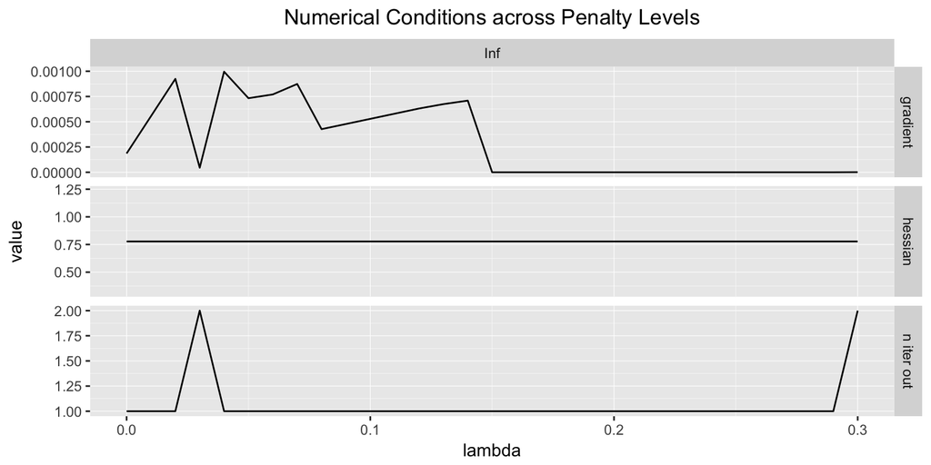

```r
r6_lslx$plot_numerical_condition()
```

The method `plot_information_criterion` shows the values of information criteria under all the penalty levels. The plot shows that an optimal value of lambda is any value larger than `0.15`.

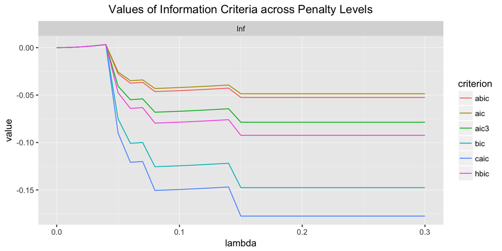

```r
r6_lslx$plot_information_criterion()
```

The method `plot_fit_indice` shows the values of fit indices under all the penalty levels.

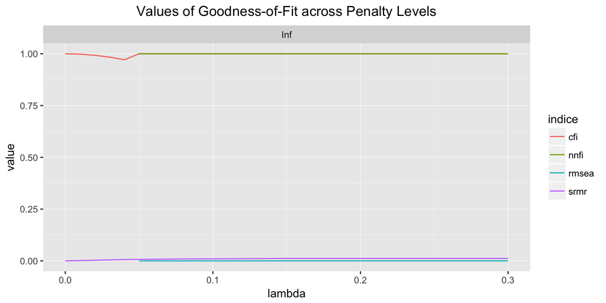

```r
r6_lslx$plot_fit_indice()
```

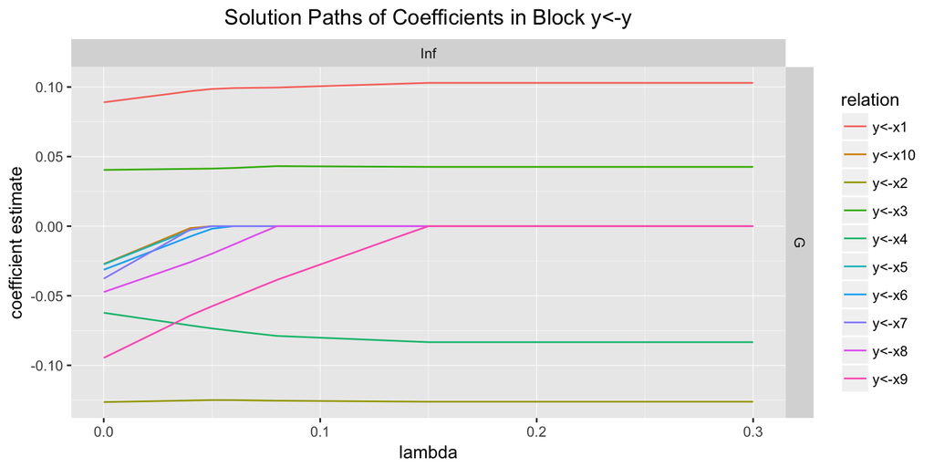

```r
r6_lslx$plot_coefficient(block = "y<-y")
```

## Objects Extraction

In `lslx`, many quantities related to SEM can be extracted by extract-related method. For example, the coefficient under the penalty level selected by `aic` can be obtained by

```r
r6_lslx$extract_coefficient(selector = "aic")
```

```
     y<-1|G     x1<-1|G     x2<-1|G     x3<-1|G     x4<-1|G     x5<-1|G     x6<-1|G     x7<-1|G
   -0.00247    -0.03294    -0.08263     0.07199    -0.02508    -0.05018    -0.09601     0.02681
    x8<-1|G     x9<-1|G    x10<-1|G     y<-x1|G     y<-x2|G     y<-x3|G     y<-x4|G     y<-x5|G
    0.04775     0.00111     0.02436     0.10294    -0.12611     0.04260    -0.08332     0.00000
    y<-x6|G     y<-x7|G     y<-x8|G     y<-x9|G    y<-x10|G     y<->y|G   x1<->x1|G   x2<->x1|G
    0.00000     0.00000     0.00000     0.00000     0.00000     1.10422     1.20633     0.10137
  x3<->x1|G   x4<->x1|G   x5<->x1|G   x6<->x1|G   x7<->x1|G   x8<->x1|G   x9<->x1|G  x10<->x1|G
    0.07090     0.16763     0.06901    -0.28053    -0.05460     0.08263    -0.08223    -0.02676
  x2<->x2|G   x3<->x2|G   x4<->x2|G   x5<->x2|G   x6<->x2|G   x7<->x2|G   x8<->x2|G   x9<->x2|G
    1.16405     0.04209    -0.01149     0.01977    -0.14231     0.03125     0.01724     0.01193
 x10<->x2|G   x3<->x3|G   x4<->x3|G   x5<->x3|G   x6<->x3|G   x7<->x3|G   x8<->x3|G   x9<->x3|G
   -0.04697     1.03484    -0.05058    -0.09476     0.08204     0.07300    -0.11996     0.00334
 x10<->x3|G   x4<->x4|G   x5<->x4|G   x6<->x4|G   x7<->x4|G   x8<->x4|G   x9<->x4|G  x10<->x4|G
   -0.06150     1.00971     0.07830     0.01525    -0.05398     0.17313     0.10138     0.02669
  x5<->x5|G   x6<->x5|G   x7<->x5|G   x8<->x5|G   x9<->x5|G  x10<->x5|G   x6<->x6|G   x7<->x6|G
    1.07843    -0.09960    -0.13574     0.12568    -0.06061     0.07054     1.05668     0.01436
  x8<->x6|G   x9<->x6|G  x10<->x6|G   x7<->x7|G   x8<->x7|G   x9<->x7|G  x10<->x7|G   x8<->x8|G
    0.03514     0.02572    -0.01691     0.83925    -0.08207    -0.01792    -0.09597     0.98598
  x9<->x8|G  x10<->x8|G   x9<->x9|G  x10<->x9|G x10<->x10|G
   -0.11069     0.15616     1.02171    -0.14454     0.99154
```

We may also check the quality of optimization by viewing the subgradient of objective function

```r
r6_lslx$extract_objective_gradient(selector = "aic")
```

```
                 [,1]
y<-1|G      -2.03e-09
x1<-1|G      0.00e+00
x2<-1|G      0.00e+00
x3<-1|G     -1.29e-26
x4<-1|G     -2.58e-26
x5<-1|G      6.40e-27
x6<-1|G     -6.83e-27
x7<-1|G      3.41e-27
x8<-1|G      1.88e-26
x9<-1|G      3.41e-27
x10<-1|G     0.00e+00
y<-x1|G     -7.72e-11
y<-x2|G     -3.17e-10
y<-x3|G      1.34e-10
y<-x4|G      1.41e-13
y<-x5|G      0.00e+00
y<-x6|G      0.00e+00
y<-x7|G      0.00e+00
y<-x8|G      0.00e+00
y<-x9|G      0.00e+00
y<-x10|G     0.00e+00
y<->y|G     -1.49e-10
x1<->x1|G    7.81e-18
x2<->x1|G   -2.64e-17
x3<->x1|G   -4.66e-18
x4<->x1|G   -2.60e-18
x5<->x1|G    1.04e-17
x6<->x1|G   -9.54e-18
x7<->x1|G    6.07e-18
x8<->x1|G   -1.73e-18
x9<->x1|G    6.94e-18
x10<->x1|G  -8.67e-19
x2<->x2|G   -1.90e-18
x3<->x2|G    4.34e-19
x4<->x2|G    1.73e-18
x5<->x2|G   -9.54e-18
x6<->x2|G   -2.52e-17
x7<->x2|G   -1.39e-17
x8<->x2|G    1.56e-17
```

[output cut: 23 more lines]

```
x6<->x6|G   -1.20e-17
x7<->x6|G   -1.88e-18
x8<->x6|G    3.74e-19
x9<->x6|G    3.17e-19
x10<->x6|G  -6.78e-18
x7<->x7|G    2.55e-17
x8<->x7|G   -3.83e-17
x9<->x7|G    1.44e-17
x10<->x7|G  -1.57e-17
x8<->x8|G   -2.78e-17
x9<->x8|G   -3.73e-17
x10<->x8|G   2.76e-18
x9<->x9|G   -1.41e-18
x10<->x9|G  -2.39e-18
x10<->x10|G -1.16e-18
```

The subgradient shows that the obtained solution is optimal since all the elements are very small.